# Survival Analysis

Ghazaleh Moradi

12/4/2019

**INTRO**

In this project, we build a Cox proportional Hazards model to figure out which factors such as educational level, electricity, and marriage affect to death of people in Bihar, which is a state in India in 2007.

Marital Status We assigned the values 1 to any person who was never married, 2 to any person who was married without a gauna performed or married with a gauna performed or remarried, and 3 to any person who was a widow/widower or divorced or separated. We omitted any NA/Null values.

Education We assigned the value 1 to any person with education less than college/university (ranges from illiterate to high school) and 2 to anyone with a college education or higher. NA/NULL values have been omitted.

Censored Age of Death If the subject was under 24 years old, we censored their death because they were often not married, all had very similar education levels and often may not have died.

Households with electricity was already formatted with 1 equaling having electricity and 2 meaning they do not have electricity. We also omitted any NA/NULL values.

Our other variables are:

Sex: Male=1, Female=2 Age of Death Marital Status–which we manipulated into Marital Status Category Highest Education–which was manipulated into Highest Education Category Household have Electricity Censored Age of Death

```
## 'data.frame':    17173 obs. of  8 variables:
##  $ Sex                       : int  2 1 2 1 1 1 1 2 1 2 ...
##  $ Age of Death              : int  82 48 84 62 50 24 14 21 102 77 ...
##  $ martial Status            : int  3 5 3 3 5 3 3 5 3 3 ...
##  $ Highest Education         : int  1 2 2 1 1 1 2 1 7 1 ...
##  $ Household have electricity: int  2 2 2 2 1 2 2 2 2 1 ...
##  $ Censored Age of Death     : num  1 1 1 1 1 0 0 0 1 1 ...
##  $ martial Status category   : num  2 3 2 2 3 2 2 3 2 2 ...
##  $ Highest Education Category: num  1 1 1 1 1 1 1 1 2 1 ...
##  - attr(*, "na.action")= 'omit' Named int  1361 1398 1732 3419 3553 4017 4075 5804 7845 8500 ...
##   ..- attr(*, "names")= chr  "1361" "1398" "1732" "3419" ...
```

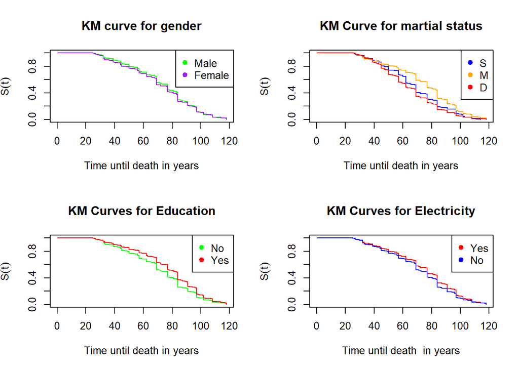

After plotting Kaplan-Meier curves, we also conduct log rank test on each variable. All of the p values are smaller than 0.05, which indicates all of these variables have significant effect on the Age of Death.

```
## Call:
## survdiff(formula = Surv(time_BH, status_BH) ~ sex_BH)
##
##             N Observed Expected (O-E)^2/E (O-E)^2/V
## sex_BH=1 9329     8072     8192      1.76      4.72
## sex_BH=2 7844     6586     6466      2.22      4.72
##
##  Chisq= 4.7  on 1 degrees of freedom, p= 0.03
```

```
## Call:
## survdiff(formula = Surv(time_BH, status_BH) ~ martial_BH)
##
##                  N Observed Expected (O-E)^2/E (O-E)^2/V
## martial_BH=1   157      146      117      7.32      8.45
## martial_BH=2 13869    11556    12481     68.56    538.82
## martial_BH=3  3147     2956     2060    389.49    528.72
##
##  Chisq= 543  on 2 degrees of freedom, p= <2e-16
```

```
## Call:
## survdiff(formula = Surv(time_BH, status_BH) ~ edu_BH)
##
##              N Observed Expected (O-E)^2/E (O-E)^2/V
## edu_BH=1 13903    11749    11264      20.9       108
## edu_BH=2  3270     2909     3394      69.3       108
##
##  Chisq= 108  on 1 degrees of freedom, p= <2e-16
```

```
## Call:
## survdiff(formula = Surv(time_BH, status_BH) ~ elec_BH)
##
##               N Observed Expected (O-E)^2/E (O-E)^2/V
## elec_BH=1  6348     5499     5903      27.7      55.1
## elec_BH=2 10825     9159     8755      18.6      55.1
##
##  Chisq= 55.1  on 1 degrees of freedom, p= 1e-13
```

```
## Call:
## survdiff(formula = Surv(time_BH, status_BH) ~ sex_BH, data = BH2007_filter)
##
##             N Observed Expected (O-E)^2/E (O-E)^2/V
## sex_BH=1 9329     8072     8192      1.76      4.72
## sex_BH=2 7844     6586     6466      2.22      4.72
##
##  Chisq= 4.7  on 1 degrees of freedom, p= 0.03
```

The p-value is 0.03, which means there is a statistically significant difference between the treatment between Male and Female of survival rates.

```
## Call:
## survdiff(formula = Surv(time_BH, status_BH) ~ martial_BH)
##
##                  N Observed Expected (O-E)^2/E (O-E)^2/V
## martial_BH=1   157      146      117      7.32      8.45
## martial_BH=2 13869    11556    12481     68.56    538.82
## martial_BH=3  3147     2956     2060    389.49    528.72
##
##  Chisq= 543  on 2 degrees of freedom, p= <2e-16
```

the p-value is less than 0.05 which means there is a siginificant difference between martial status.

```
## Call:
## survdiff(formula = Surv(time_BH, status_BH) ~ edu_BH)
##
##              N Observed Expected (O-E)^2/E (O-E)^2/V
## edu_BH=1 13903    11749    11264      20.9       108
## edu_BH=2  3270     2909     3394      69.3       108
##
##  Chisq= 108  on 1 degrees of freedom, p= <2e-16
```

the p-value is less than 0.05 which means there is a siginificant difference between education status.

```
## Call:
## survdiff(formula = Surv(time_BH, status_BH) ~ elec_BH)
##
##               N Observed Expected (O-E)^2/E (O-E)^2/V
## elec_BH=1  6348     5499     5903      27.7      55.1
## elec_BH=2 10825     9159     8755      18.6      55.1
##
##  Chisq= 55.1  on 1 degrees of freedom, p= 1e-13
```

the p-value is less than 0.05 which means there is a siginificant difference between have or not have electricity.

```
## Start:  AIC=251822.2
## Surv(time_BH, status_BH) ~ (as.factor(sex_BH + edu_BH + elec_BH +
##     martial_BH))
##
##                                                     Df    AIC
## <none>                                                 251822
## - as.factor(sex_BH + edu_BH + elec_BH + martial_BH)  5 251916
```

```
## Call:
## coxph(formula = Surv(time_BH, status_BH) ~ (as.factor(sex_BH +
##     edu_BH + elec_BH + martial_BH)), data = BH2007_filter)
##
##                                                        coef exp(coef) se(coef)
## as.factor(sex_BH + edu_BH + elec_BH + martial_BH)5 -0.21360   0.80767  0.21007
## as.factor(sex_BH + edu_BH + elec_BH + martial_BH)6 -0.16099   0.85130  0.20893
## as.factor(sex_BH + edu_BH + elec_BH + martial_BH)7 -0.06326   0.93870  0.20896
## as.factor(sex_BH + edu_BH + elec_BH + martial_BH)8  0.06659   1.06885  0.21042
## as.factor(sex_BH + edu_BH + elec_BH + martial_BH)9  0.47997   1.61603  0.23876
##                                                         z      p
## as.factor(sex_BH + edu_BH + elec_BH + martial_BH)5 -1.017 0.3093
## as.factor(sex_BH + edu_BH + elec_BH + martial_BH)6 -0.771 0.4410
## as.factor(sex_BH + edu_BH + elec_BH + martial_BH)7 -0.303 0.7621
## as.factor(sex_BH + edu_BH + elec_BH + martial_BH)8  0.316 0.7517
## as.factor(sex_BH + edu_BH + elec_BH + martial_BH)9  2.010 0.0444
##
## Likelihood ratio test=104  on 5 df, p=< 2.2e-16
## n= 17173, number of events= 14658
```

```
## Start:  AIC=251822.2
## Surv(time_BH, status_BH) ~ (as.factor(sex_BH + edu_BH + elec_BH +
##     martial_BH))
```

```
## Call:
## coxph(formula = Surv(time_BH, status_BH) ~ (as.factor(sex_BH +
##     edu_BH + elec_BH + martial_BH)), data = BH2007_filter)
##
##                                                        coef exp(coef) se(coef)
## as.factor(sex_BH + edu_BH + elec_BH + martial_BH)5 -0.21360   0.80767  0.21007
## as.factor(sex_BH + edu_BH + elec_BH + martial_BH)6 -0.16099   0.85130  0.20893
## as.factor(sex_BH + edu_BH + elec_BH + martial_BH)7 -0.06326   0.93870  0.20896
## as.factor(sex_BH + edu_BH + elec_BH + martial_BH)8  0.06659   1.06885  0.21042
## as.factor(sex_BH + edu_BH + elec_BH + martial_BH)9  0.47997   1.61603  0.23876
##                                                         z      p
## as.factor(sex_BH + edu_BH + elec_BH + martial_BH)5 -1.017 0.3093
## as.factor(sex_BH + edu_BH + elec_BH + martial_BH)6 -0.771 0.4410
## as.factor(sex_BH + edu_BH + elec_BH + martial_BH)7 -0.303 0.7621
## as.factor(sex_BH + edu_BH + elec_BH + martial_BH)8  0.316 0.7517
## as.factor(sex_BH + edu_BH + elec_BH + martial_BH)9  2.010 0.0444
##
## Likelihood ratio test=104  on 5 df, p=< 2.2e-16
## n= 17173, number of events= 14658
```

|  | loglik | Chisq | Df | Pr(>\|Chi\|) |
| --- | --- | --- | --- | --- |
| NULL | -125958.1 | NA | NA | NA |
| sex_BH | -125956.3 | 3.686911 | 1 | 5.484110e-02 |
| edu_BH | -125904.2 | 104.081539 | 1 | 1.941589e-24 |
| elec_BH | -125889.7 | 29.104484 | 1 | 6.857808e-08 |
| martial_BH | -125710.0 | 359.373456 | 1 | 3.854894e-80 |

```
## [1] 348.9573
```

```
## [1] 7.148364e-78
```

```
## [1] 34.91991
```

```
## [1] 3.435503e-09
```

```
## [1] 7.951206
```

```
## [1] 0.004805534
```

```
##         chisq df       p
## edu_BH   21.8  1 3.1e-06
## elec_BH  11.6  1 0.00067
```

```
## Call:
## coxph(formula = Surv(time_BH, status_BH) ~ strata(martial_BH) *
##     edu_BH)
##
##   n= 17173, number of events= 14658
##
##                                           coef exp(coef) se(coef)      z
## edu_BH                                -0.08833   0.91546  0.18663 -0.473
## strata(martial_BH)martial_BH=2:edu_BH -0.08808   0.91568  0.18796 -0.469
## strata(martial_BH)martial_BH=3:edu_BH  0.06538   1.06757  0.19659  0.333
##                                       Pr(>|z|)
## edu_BH                                   0.636
## strata(martial_BH)martial_BH=2:edu_BH    0.639
## strata(martial_BH)martial_BH=3:edu_BH    0.739
##
##                                       exp(coef) exp(-coef) lower .95 upper .95
## edu_BH                                   0.9155     1.0923    0.6350     1.320
## strata(martial_BH)martial_BH=2:edu_BH    0.9157     1.0921    0.6335     1.324
## strata(martial_BH)martial_BH=3:edu_BH    1.0676     0.9367    0.7262     1.569
##
## Concordance= 0.521  (se = 0.002 )
## Likelihood ratio test= 64.61  on 3 df,   p=6e-14
## Wald test            = 62.6  on 3 df,   p=2e-13
## Score (logrank) test = 62.76  on 3 df,   p=2e-13
```

```
## Call:
## coxph(formula = Surv(time_BH, status_BH) ~ strata(martial_BH) *
##     elec_BH)
##
##   n= 17173, number of events= 14658
##
##                                           coef exp(coef) se(coef)      z
## elec_BH                                 0.3420    1.4078   0.1756  1.948
## strata(martial_BH)martial_BH=2:elec_BH -0.2083    0.8120   0.1766 -1.179
## strata(martial_BH)martial_BH=3:elec_BH -0.2646    0.7675   0.1796 -1.473
##                                        Pr(>|z|)
## elec_BH                                  0.0514 .
## strata(martial_BH)martial_BH=2:elec_BH   0.2382
## strata(martial_BH)martial_BH=3:elec_BH   0.1407
## ---
## Signif. codes:  0 '***' 0.001 '**' 0.01 '*' 0.05 '.' 0.1 ' ' 1
##
##                                        exp(coef) exp(-coef) lower .95 upper .95
## elec_BH                                   1.4078     0.7103    0.9979     1.986
## strata(martial_BH)martial_BH=2:elec_BH    0.8120     1.2316    0.5744     1.148
## strata(martial_BH)martial_BH=3:elec_BH    0.7675     1.3029    0.5398     1.091
##
## Concordance= 0.521  (se = 0.003 )
## Likelihood ratio test= 56.84  on 3 df,   p=3e-12
## Wald test            = 56.19  on 3 df,   p=4e-12
## Score (logrank) test = 56.3  on 3 df,   p=4e-12
```

```
## Call:
## coxph(formula = Surv(time_BH, status_BH) ~ strata(martial_BH) *
##     sex_BH)
##
##   n= 17173, number of events= 14658
##
##                                           coef exp(coef) se(coef)     z
## sex_BH                                0.006997  1.007021 0.178587 0.039
## strata(martial_BH)martial_BH=2:sex_BH 0.048988  1.050208 0.179559 0.273
## strata(martial_BH)martial_BH=3:sex_BH 0.020130  1.020334 0.182510 0.110
##                                       Pr(>|z|)
## sex_BH                                   0.969
## strata(martial_BH)martial_BH=2:sex_BH    0.785
## strata(martial_BH)martial_BH=3:sex_BH    0.912
##
##                                       exp(coef) exp(-coef) lower .95 upper .95
## sex_BH                                    1.007     0.9930    0.7096     1.429
## strata(martial_BH)martial_BH=2:sex_BH     1.050     0.9522    0.7386     1.493
## strata(martial_BH)martial_BH=3:sex_BH     1.020     0.9801    0.7135     1.459
##
## Concordance= 0.515  (se = 0.003 )
## Likelihood ratio test= 9.51  on 3 df,   p=0.02
## Wald test            = 9.53  on 3 df,   p=0.02
## Score (logrank) test = 9.53  on 3 df,   p=0.02
```

Using the likelihood test, we chose one of the most significan variable (education and martial status)and add each varibles one by one to the model, to find out the model. Same model got obtained as using backward elimination method. All varibles must be included in the model.

**Model Checking**

Since we are building the Cox PH model, we need to make sure all four covariates meet the Cox PH assumption. We use both residual tests and C-log-log plots to check Cox PH assumption:

**residual test**

```
##            chisq df       p
## edu_BH      33.9  1 5.9e-09
## martial_BH  63.4  1 1.7e-15
## elec_BH     10.3  1  0.0013
## sex_BH      28.9  1 7.5e-08
```

**C-log-log plot**

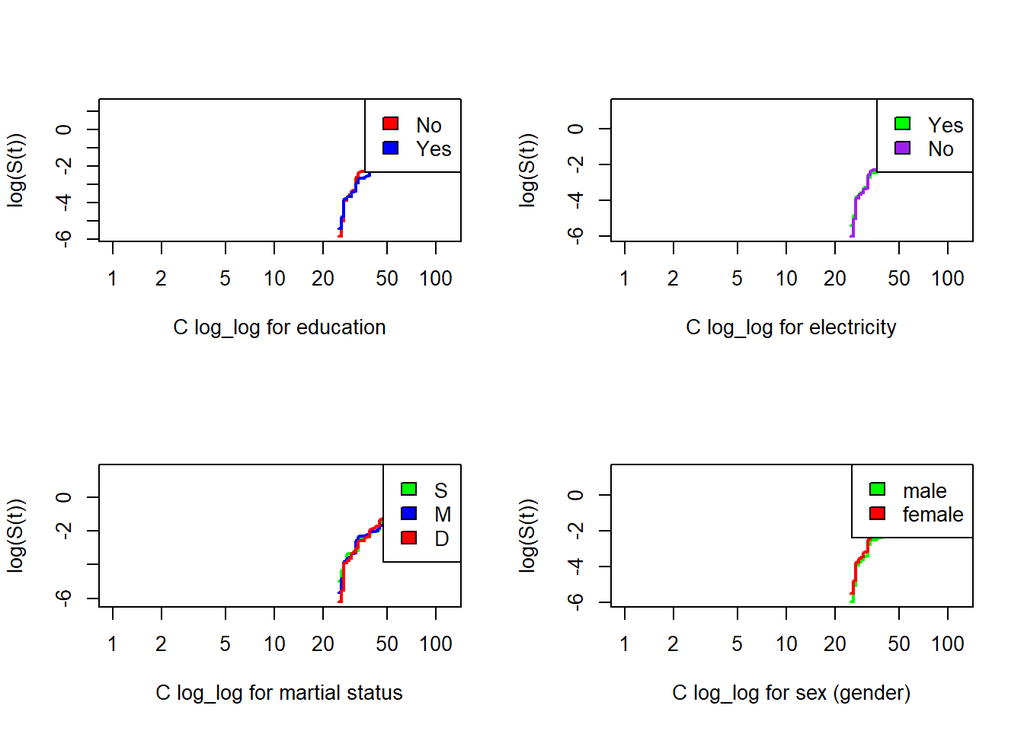

**Interaction term**

An interaction occurs when an independent variable has a different effect on the outcome depending on the values of another independent variable.

```
## Call:
## coxph(formula = Surv(time_BH, status_BH) ~ sex_BH * edu_BH)
##
##   n= 17173, number of events= 14658
##
##                   coef exp(coef) se(coef)      z Pr(>|z|)
## sex_BH        -0.09389   0.91039  0.05255 -1.787   0.0740 .
## edu_BH        -0.35778   0.69923  0.06410 -5.582 2.38e-08 ***
## sex_BH:edu_BH  0.10371   1.10928  0.04157  2.495   0.0126 *
## ---
## Signif. codes:  0 '***' 0.001 '**' 0.01 '*' 0.05 '.' 0.1 ' ' 1
##
##               exp(coef) exp(-coef) lower .95 upper .95
## sex_BH           0.9104     1.0984    0.8213    1.0092
## edu_BH           0.6992     1.4301    0.6167    0.7928
## sex_BH:edu_BH    1.1093     0.9015    1.0225    1.2034
##
## Concordance= 0.529  (se = 0.003 )
## Likelihood ratio test= 114  on 3 df,   p=<2e-16
## Wald test            = 108.3  on 3 df,   p=<2e-16
## Score (logrank) test = 108.8  on 3 df,   p=<2e-16
```

|  | loglik | Chisq | Df | Pr(>\|Chi\|) |
| --- | --- | --- | --- | --- |
| NULL | -125958.1 | NA | NA | NA |
| sex_BH | -125956.3 | 3.686911 | 1 | 5.484110e-02 |
| edu_BH | -125904.2 | 104.081539 | 1 | 1.941589e-24 |
| sex_BH:edu_BH | -125901.1 | 6.212695 | 1 | 1.268374e-02 |

```
## Call:
## coxph(formula = Surv(time_BH, status_BH) ~ sex_BH * martial_BH)
##
##   n= 17173, number of events= 14658
##
##                       coef exp(coef) se(coef)      z Pr(>|z|)
## sex_BH             0.08140   1.08481  0.09227  0.882    0.378
## martial_BH         0.44753   1.56444  0.06191  7.229 4.87e-13 ***
## sex_BH:martial_BH -0.01671   0.98343  0.04152 -0.402    0.687
## ---
## Signif. codes:  0 '***' 0.001 '**' 0.01 '*' 0.05 '.' 0.1 ' ' 1
##
##                   exp(coef) exp(-coef) lower .95 upper .95
## sex_BH               1.0848     0.9218    0.9053     1.300
## martial_BH           1.5644     0.6392    1.3857     1.766
## sex_BH:martial_BH    0.9834     1.0169    0.9066     1.067
##
## Concordance= 0.553  (se = 0.003 )
## Likelihood ratio test= 399.4  on 3 df,   p=<2e-16
## Wald test            = 429.5  on 3 df,   p=<2e-16
## Score (logrank) test = 433.3  on 3 df,   p=<2e-16
```

|  | loglik | Chisq | Df | Pr(>\|Chi\|) |
| --- | --- | --- | --- | --- |
| NULL | -125958.1 | NA | NA | NA |
| sex_BH | -125956.3 | 3.6869108 | 1 | 5.484110e-02 |
| martial_BH | -125758.5 | 395.5177408 | 1 | 5.208105e-88 |
| sex_BH:martial_BH | -125758.4 | 0.1621124 | 1 | 6.872191e-01 |

```
## Call:
## coxph(formula = Surv(time_BH, status_BH) ~ sex_BH * elec_BH)
##
##   n= 17173, number of events= 14658
##
##                     coef exp(coef)  se(coef)      z Pr(>|z|)
## sex_BH         -0.092950  0.911239  0.058106 -1.600   0.1097
## elec_BH         0.008933  1.008973  0.052616  0.170   0.8652
## sex_BH:elec_BH  0.079067  1.082277  0.034286  2.306   0.0211 *
## ---
## Signif. codes:  0 '***' 0.001 '**' 0.01 '*' 0.05 '.' 0.1 ' ' 1
##
##                exp(coef) exp(-coef) lower .95 upper .95
## sex_BH            0.9112     1.0974    0.8132     1.021
## elec_BH           1.0090     0.9911    0.9101     1.119
## sex_BH:elec_BH    1.0823     0.9240    1.0119     1.158
##
## Concordance= 0.524  (se = 0.003 )
## Likelihood ratio test= 62.12  on 3 df,   p=2e-13
## Wald test            = 62.06  on 3 df,   p=2e-13
## Score (logrank) test = 62.16  on 3 df,   p=2e-13
```

|  | loglik | Chisq | Df | Pr(>\|Chi\|) |
| --- | --- | --- | --- | --- |
| NULL | -125958.1 | NA | NA | NA |
| sex_BH | -125956.3 | 3.686911 | 1 | 5.484110e-02 |
| elec_BH | -125929.7 | 53.107775 | 1 | 3.157402e-13 |
| sex_BH:elec_BH | -125927.1 | 5.320491 | 1 | 2.107607e-02 |

```
## Call:
## coxph(formula = Surv(time_BH, status_BH) ~ edu_BH * martial_BH)
##
##   n= 17173, number of events= 14658
##
##                       coef exp(coef) se(coef)      z Pr(>|z|)
## edu_BH            -0.28804   0.74973  0.13855 -2.079   0.0376 *
## martial_BH         0.33265   1.39466  0.07537  4.414 1.02e-05 ***
## edu_BH:martial_BH  0.06031   1.06217  0.06519  0.925   0.3549
## ---
## Signif. codes:  0 '***' 0.001 '**' 0.01 '*' 0.05 '.' 0.1 ' ' 1
##
##                   exp(coef) exp(-coef) lower .95 upper .95
## edu_BH               0.7497     1.3338    0.5714    0.9836
## martial_BH           1.3947     0.7170    1.2031    1.6167
## edu_BH:martial_BH    1.0622     0.9415    0.9348    1.2069
##
## Concordance= 0.558  (se = 0.002 )
## Likelihood ratio test= 454.2  on 3 df,   p=<2e-16
## Wald test            = 479.3  on 3 df,   p=<2e-16
## Score (logrank) test = 484.7  on 3 df,   p=<2e-16
```

|  | loglik | Chisq | Df | Pr(>\|Chi\|) |
| --- | --- | --- | --- | --- |
| NULL | -125958.1 | NA | NA | NA |
| edu_BH | -125905.9 | 104.4179920 | 1 | 1.638361e-24 |
| martial_BH | -125731.4 | 348.9572844 | 1 | 7.148364e-78 |
| edu_BH:martial_BH | -125731.0 | 0.8468308 | 1 | 3.574504e-01 |

```r
#model with interaction term
fitSC.int4 = coxph(Surv(time_BH,status_BH)~edu_BH*elec_BH)
summary(fitSC.int4)
```

```
## Call:
## coxph(formula = Surv(time_BH, status_BH) ~ edu_BH * elec_BH)
##
##   n= 17173, number of events= 14658
##
##                    coef exp(coef) se(coef)      z Pr(>|z|)
## edu_BH         -0.09010   0.91384  0.06616 -1.362  0.17321
## elec_BH         0.17130   1.18684  0.05435  3.152  0.00162 **
## edu_BH:elec_BH -0.06482   0.93724  0.04233 -1.531  0.12573
## ---
## Signif. codes:  0 '***' 0.001 '**' 0.01 '*' 0.05 '.' 0.1 ' ' 1
##
##                exp(coef) exp(-coef) lower .95 upper .95
## edu_BH            0.9138     1.0943    0.8027     1.040
## elec_BH           1.1868     0.8426    1.0669     1.320
## edu_BH:elec_BH    0.9372     1.0670    0.8626     1.018
##
## Concordance= 0.533  (se = 0.003 )
## Likelihood ratio test= 135.2  on 3 df,   p=<2e-16
## Wald test            = 131.7  on 3 df,   p=<2e-16
## Score (logrank) test = 132.3  on 3 df,   p=<2e-16
```

```r
anova(fitSC.int4)
```

|  | loglik | Chisq | Df | Pr(>\|Chi\|) |
| --- | --- | --- | --- | --- |
| NULL | -125958.1 | NA | NA | NA |
| edu_BH | -125905.9 | 104.417992 | 1 | 1.638361e-24 |
| elec_BH | -125891.7 | 28.479957 | 1 | 9.467349e-08 |
| edu_BH:elec_BH | -125890.5 | 2.349638 | 1 | 1.253121e-01 |

```
## Call:
## coxph(formula = Surv(time_BH, status_BH) ~ martial_BH * elec_BH)
##
##   n= 17173, number of events= 14658
##
##                        coef exp(coef) se(coef)      z Pr(>|z|)
## martial_BH          0.50125   1.65078  0.07069  7.090 1.34e-12 ***
## elec_BH             0.23132   1.26026  0.09346  2.475   0.0133 *
## martial_BH:elec_BH -0.04867   0.95249  0.04188 -1.162   0.2451
## ---
## Signif. codes:  0 '***' 0.001 '**' 0.01 '*' 0.05 '.' 0.1 ' ' 1
##
##                    exp(coef) exp(-coef) lower .95 upper .95
## martial_BH            1.6508     0.6058    1.4372     1.896
## elec_BH               1.2603     0.7935    1.0493     1.514
## martial_BH:elec_BH    0.9525     1.0499    0.8774     1.034
##
## Concordance= 0.557  (se = 0.003 )
## Likelihood ratio test= 447  on 3 df,   p=<2e-16
## Wald test            = 474.5  on 3 df,   p=<2e-16
## Score (logrank) test = 479.4  on 3 df,   p=<2e-16
```

|  | loglik | Chisq | Df | Pr(>\|Chi\|) |
| --- | --- | --- | --- | --- |
| NULL | -125958.1 | NA | NA | NA |
| martial_BH | -125762.2 | 391.933128 | 1 | 3.140767e-87 |
| elec_BH | -125735.3 | 53.744934 | 1 | 2.282821e-13 |
| martial_BH:elec_BH | -125734.6 | 1.348108 | 1 | 2.456092e-01 |

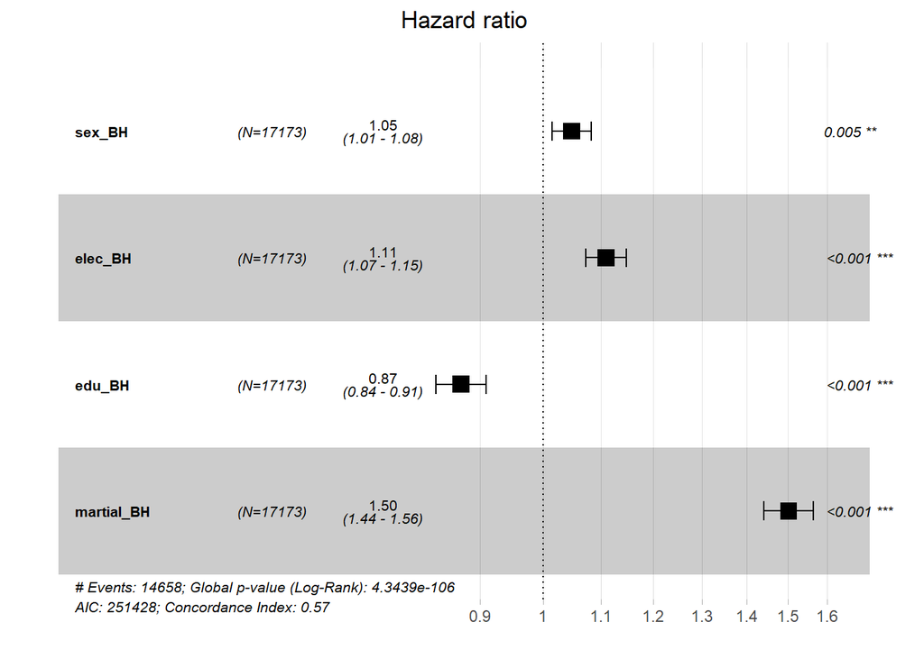

```
##
## Call:
## survreg(formula = BH_surv ~ sex_BH + edu_BH + elec_BH + martial_BH,
##     dist = "loglogistic")
##                Value Std. Error       z       p
## (Intercept)  4.63685    0.02454  188.96 < 2e-16
## sex_BH      -0.03197    0.00589   -5.43 5.7e-08
## edu_BH       0.05402    0.00743    7.27 3.5e-13
## elec_BH     -0.03514    0.00615   -5.71 1.1e-08
## martial_BH  -0.15234    0.00715  -21.32 < 2e-16
## Log(scale)  -1.58785    0.00694 -228.83 < 2e-16
##
## Scale= 0.204
##
## Log logistic distribution
## Loglik(model)= -67957.8   Loglik(intercept only)= -68267.8
##  Chisq= 619.92 on 4 degrees of freedom, p= 7.6e-133
## Number of Newton-Raphson Iterations: 6
## n= 17173
```

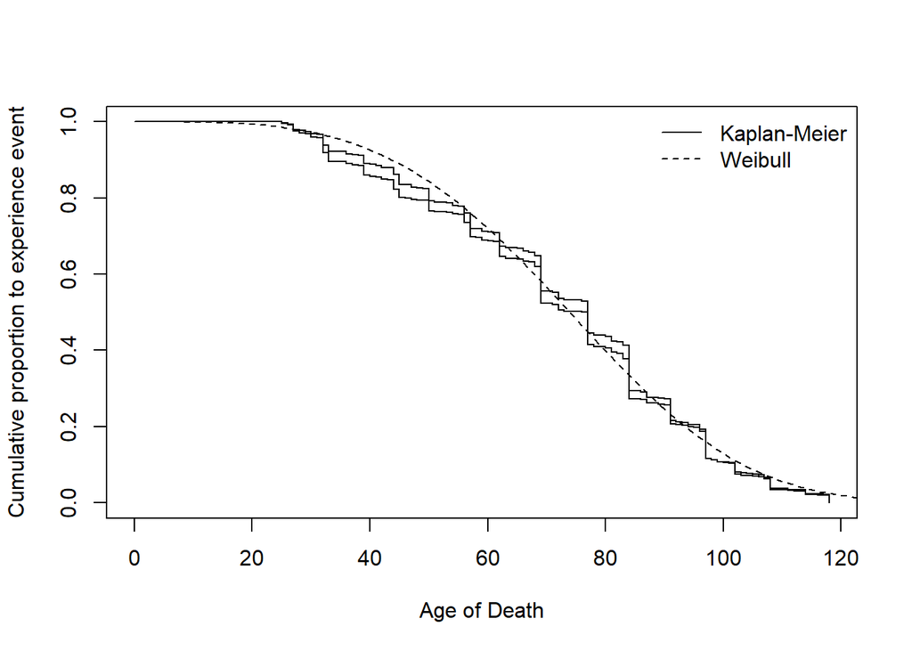

```r
library(survival)
addict.we <- survreg(Surv(time_BH, status_BH) ~ sex_BH, dist = "weibull")
addict.km <- survfit(Surv(time_BH, status_BH) ~ sex_BH, conf.type = "none", type ="kaplan-meier")
p <- 1 / addict.we$scale
lambda <- exp(-addict.we$coefficients [1])
t <- 1:1000
St <- exp(-(lambda * t)^p)
addict.we <- as.data.frame(cbind(t = t, St = St))
plot(addict.km, xlab = "Age of Death", ylab = "Cumulative proportion to experience event")
lines(addict.we$t, addict.we$St, lty = 2)
legend(x = "topright", legend = c("Kaplan-Meier", "Weibull"), lty = c(1,2), bty = "n")
```

```r
#addict.km <- survfit(Surv(time_BH, status_BH) ~ 1, conf.type = "none", type ="kaplan-meier")
#Ht <- -log(addict.km$surv)
#t <- addict.km$time
#par(pty = "s", mfrow = c(1,2))
#plot(t, Ht, type = "s", xlim = c(0, 1000),xlab = "Days to relapse", ylab = "Cumulative hazard", lwd = 2)
#plot(log(t), log(Ht), type = "s", xlim = c(0, 7), xlab = "Days to relapse(log)", ylab = "Cumulative hazard (log)", lwd = 2)
```

```r
# library(rms)
# BH2007_filter$Sex <- factor(BH2007_filter$Sex, levels = c(1, 2), labels = c("1", "2"))
# contrasts(BH2007_filter$Sex) <- contr.treatment(2, base = 1, contrasts = TRUE)
# BH2007_filter$`Highest Education Category` <- factor(BH2007_filter$`Highest Education Category`, levels = c(2, 3), labels = c("2", "3"))
# contrasts(BH2007_filter$`Highest Education Category`) <- contr.treatment(2, base = 1, contrasts = TRUE)
# addict.wei01 = survreg(Surv(time_BH, status_BH, type = "right") ~ sex_BH+edu_BH+elec_BH+martial_BH, dist = "weibull")
# addict.wei <- psm(Surv(time_BH, status_BH) ~ sex_BH+edu_BH+elec_BH+martial_BH, dist = "weibull")
# #survplot(addict.wei, what = "survival", sex_BH = c("1","2"), edu_BH = "2", elec_BH = 1, martial_BH = 2)
# survplot(addict.wei, what = "hazard", sex_BH= c("1","2"), edu_BH = "2", elec_BH = 1, martial_BH = 2)
# addict.aft01 <- psm(Surv(time_BH, status_BH) ~ sex_BH+edu_BH+elec_BH+martial_BH, dist ="weibull")
# addict.aft01$coefficients[2]
# log.t <- as.numeric(addict.aft01$coefficients[1] + (addict.aft01$coefficients[2]* 1))
# log.t
```

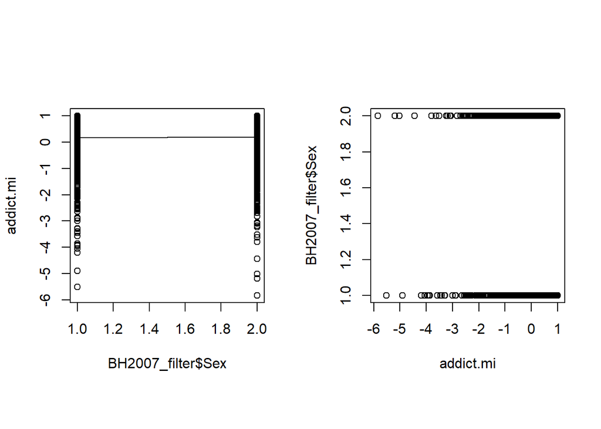

```r
addict.cph01 <- coxph(Surv(time_BH, status_BH) ~ sex_BH+edu_BH+elec_BH+martial_BH, method = "breslow")
addict.mi <- residuals(addict.cph01, type = "martingale")
addict.hi <- BH2007_filter$`Censored Age of Death` - addict.mi
addict.clsm <- lowess(BH2007_filter$Sex, BH2007_filter$`Censored Age of Death`)
addict.hlsm <- lowess(sex_BH+edu_BH+elec_BH+martial_BH, addict.hi)
addict.yi <- log(addict.clsm$y / addict.hlsm$y) + (addict.cph01$coefficients[3] * BH2007_filter$Sex)

par(pty = "s", mfrow = c(1,2))
plot(BH2007_filter$Sex, addict.mi)
lines(lowess(BH2007_filter$Sex, addict.mi))
plot(addict.mi, BH2007_filter$Sex)
```